# Activity Quality Prediction

Todd Kemmerling

September 17, 2016

## Loading the data and test sets

```r
df <- read.csv('pml-training.csv')
tt <- read.csv('pml-testing.csv')
ncolumns <- ncol(df)
```

The initial number of columns in the data frame is 160 columns.

## Reducing the number of features

The number of features/columns was reduced by eliminating empty columns and columns that have large numbers of missing values. This reduced the data set to the following columns.

```r
allUsedColumns <- c("user_name","roll_belt","pitch_belt","yaw_belt","total_accel_belt",
                    "gyros_belt_x","gyros_belt_y","gyros_belt_z","accel_belt_x","accel_belt_y",
                    "accel_belt_z", "magnet_belt_x","magnet_belt_y","magnet_belt_z","roll_arm",
                    "pitch_arm", "yaw_arm", "total_accel_arm", "gyros_arm_x", "gyros_arm_y",
                    "gyros_arm_z", "accel_arm_x", "accel_arm_y", "accel_arm_z", "magnet_arm_x",
                    "magnet_arm_y", "magnet_arm_z", "roll_dumbbell", "pitch_dumbbell", "yaw_dumbbell",
                    "total_accel_dumbbell", "gyros_dumbbell_x", "gyros_dumbbell_y", "gyros_dumbbell_z",
                    "accel_dumbbell_x", "accel_dumbbell_y","accel_dumbbell_z","magnet_dumbbell_x",
                    "magnet_dumbbell_y","magnet_dumbbell_z", "roll_forearm","pitch_forearm","yaw_forearm",
                    "total_accel_forearm", "gyros_forearm_x","gyros_forearm_y", "gyros_forearm_z",
                    "accel_forearm_x", "accel_forearm_y", "accel_forearm_z","magnet_forearm_x",
                    "magnet_forearm_y", "magnet_forearm_z","classe")
ncolumns <- length(allUsedColumns)
df <- df[,allUsedColumns]
```

This using this simple method the number of columns was reduced to 54.

## Initial Setup and Model Selection

The setup for model training is as follows.

```r
labelName <- 'classe'
predictors <- names(df)[names(df) != labelName]
set.seed(819)
```

The training is setup for cross validation with 5 kfolds.

```r
model <- train(classe~., data=df, trControl=trainControl(method="cv",number=5), method="rf")
```

```
print(model$finalModel)

randomForest(x = x, y = y, mtry = param$mtry)
               Type of random forest: classification
                     Number of trees: 500
No. of variables tried at each split: 29

        OOB estimate of  error rate: 0.42%
Confusion matrix:
     A    B    C    D    E class.error
A 5574    3    1    0    2 0.001075269
B   19 3773    5    0    0 0.006320780
C    0    9 3402   11    0 0.005844535
D    0    0   21 3193    2 0.007151741
E    0    1    3    6 3597 0.002772387
```

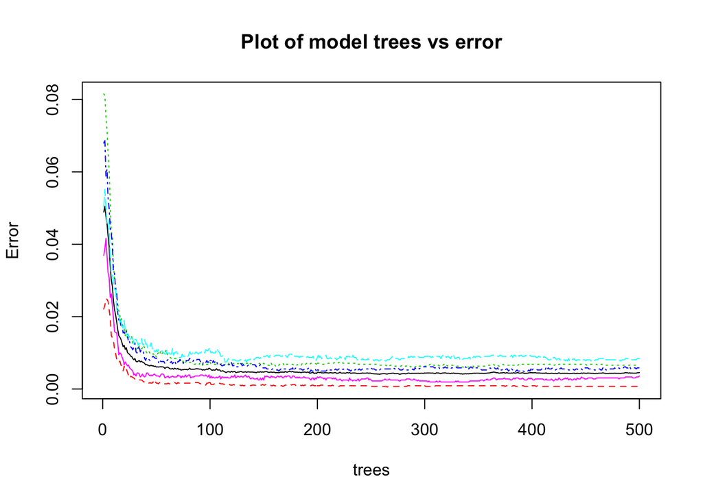

```r
plot(model$finalModel, main='Plot of model trees vs error')
```

```r
predictedValues <- predict(model, tt[,predictors])
predictedValues
```

```
##  [1] B A B A A E D B A A B C B A E E A B B B
## Levels: A B C D E
```

## Summary

The data above shows an estimated error rate of 0.42% after. The predicted values shown above were used for the quiz and the resulting grade is/was 100%. It is believed that the number of feature could be reduced further, but that work as not been done at this time.